# LBB6

Reynard Verill

February 3, 2021

# Objectives

This report is going to predict whether a passenger will survive the disastrous and infamous crash of the prominent titanic ship based on multiple predictor variables such as gender, age, ticket fare, etc.

# Library and Setup

Importing the necessary packages for the processing of the titanic data frame.

```r
library(caret) # For data pre-processing
library(dplyr)
library(tidymodels)
```

```r
library(ggplot2) # To visualize data
library(class)
library(tidyr)
library(GGally)
library(inspectdf)
library(gridExtra)
library(e1071) #for naiveBayes
theme_set(theme_minimal() +
            theme(legend.position = "top"))

options(scipen = 999)
```

# Read data

The titanic data set was obtained from Kaggle and comprises of variables as illustrated in the following table along with their respective data types :

```r
titanic_train <- read.csv("data_input/train.csv")
titanic_test <- read.csv("data_input/test.csv")
answer <- read.csv("data_input/gender_submission.csv")
glimpse(titanic_train)
```

```
## Rows: 891
## Columns: 12
## $ PassengerId <int> 1, 2, 3, 4, 5, 6, 7, 8, 9, 10, 11, 12, 13, 14, 15, 16, 17…
## $ Survived    <int> 0, 1, 1, 1, 0, 0, 0, 0, 1, 1, 1, 1, 0, 0, 0, 1, 0, 1, 0, …
## $ Pclass      <int> 3, 1, 3, 1, 3, 3, 1, 3, 3, 2, 3, 1, 3, 3, 3, 2, 3, 2, 3, …
## $ Name        <chr> "Braund, Mr. Owen Harris", "Cumings, Mrs. John Bradley (F…
## $ Sex         <chr> "male", "female", "female", "female", "male", "male", "ma…
## $ Age         <dbl> 22, 38, 26, 35, 35, NA, 54, 2, 27, 14, 4, 58, 20, 39, 14,…
## $ SibSp       <int> 1, 1, 0, 1, 0, 0, 0, 3, 0, 1, 1, 0, 0, 1, 0, 0, 4, 0, 1, …
## $ Parch       <int> 0, 0, 0, 0, 0, 0, 0, 1, 2, 0, 1, 0, 0, 5, 0, 0, 1, 0, 0, …
## $ Ticket      <chr> "A/5 21171", "PC 17599", "STON/O2. 3101282", "113803", "3…
## $ Fare        <dbl> 7.2500, 71.2833, 7.9250, 53.1000, 8.0500, 8.4583, 51.8625…
## $ Cabin       <chr> "", "C85", "", "C123", "", "", "E46", "", "", "", "G6", "…
## $ Embarked    <chr> "S", "C", "S", "S", "S", "Q", "S", "S", "S", "C", "S", "S…
```

A full set of titanic train data frame:

```r
titanic_train
```

| PassengerId | Survived | Pclass | Name | Sex | Age | SibSp | Parch | Ticket | Fare | Cabin | Embarked |
| --- | --- | --- | --- | --- | --- | --- | --- | --- | --- | --- | --- |
| 1 | 0 | 3 | Braund, Mr. Owen Harris | male | 22.00 | 1 | 0 | A/5 21171 | 7.2500 |  | S |
| 2 | 1 | 1 | Cumings, Mrs. John Bradley (Florence Briggs Thayer) | female | 38.00 | 1 | 0 | PC 17599 | 71.2833 | C85 | C |
| 3 | 1 | 3 | Heikkinen, Miss. Laina | female | 26.00 | 0 | 0 | STON/O2. 3101282 | 7.9250 |  | S |
| 4 | 1 | 1 | Futrelle, Mrs. Jacques Heath (Lily May Peel) | female | 35.00 | 1 | 0 | 113803 | 53.1000 | C123 | S |
| 5 | 0 | 3 | Allen, Mr. William Henry | male | 35.00 | 0 | 0 | 373450 | 8.0500 |  | S |
| 6 | 0 | 3 | Moran, Mr. James | male | NA | 0 | 0 | 330877 | 8.4583 |  | Q |
| 7 | 0 | 1 | McCarthy, Mr. Timothy J | male | 54.00 | 0 | 0 | 17463 | 51.8625 | E46 | S |
| 8 | 0 | 3 | Palsson, Master. Gosta Leonard | male | 2.00 | 3 | 1 | 349909 | 21.0750 |  | S |
| 9 | 1 | 3 | Johnson, Mrs. Oscar W (Elisabeth Vilhelmina Berg) | female | 27.00 | 0 | 2 | 347742 | 11.1333 |  | S |
| 10 | 1 | 2 | Nasser, Mrs. Nicholas (Adele Achem) | female | 14.00 | 1 | 0 | 237736 | 30.0708 |  | C |

[output cut: 881 more lines]

Columns descriptions: Survived : Indicates the survival of the passenger (1 for yes, and 0 for no). Pclass : Ticket class (1 = 1st, 2 = 2nd, 3 = 3rd) Sex : Sex of the passenger. Age : Age in years. sibsp : # of siblings / spouses aboard the Titanic  
Parch : # of parents / children aboard the Titanic  
Ticket : Ticket number  
Fare : Passenger fare  
Cabin : Cabin number  
Embarked : Port of Embarkation (C = Cherbourg, Q = Queenstown, S = Southampton)

```r
answer
```

| PassengerId | Survived |
| --- | --- |
| 892 | 0 |
| 893 | 1 |
| 894 | 0 |
| 895 | 0 |
| 896 | 1 |
| 897 | 0 |
| 898 | 1 |
| 899 | 0 |
| 900 | 1 |
| 901 | 0 |

[output cut: 408 more lines]

# Data Wrangling

In this section, the titanic data frames are going to be analyzed first before further processing, and ultimately modeling.

## Remove unused columns

```r
titanic_train <- titanic_train %>% select(-c("PassengerId", "Name", "Ticket", "Cabin"))
titanic_test <- titanic_test %>% select(-c("PassengerId", "Name", "Ticket", "Cabin"))

titanic_train %>% glimpse
```

```
## Rows: 891
## Columns: 8
## $ Survived <int> 0, 1, 1, 1, 0, 0, 0, 0, 1, 1, 1, 1, 0, 0, 0, 1, 0, 1, 0, 1, …
## $ Pclass   <int> 3, 1, 3, 1, 3, 3, 1, 3, 3, 2, 3, 1, 3, 3, 3, 2, 3, 2, 3, 3, …
## $ Sex      <chr> "male", "female", "female", "female", "male", "male", "male"…
## $ Age      <dbl> 22, 38, 26, 35, 35, NA, 54, 2, 27, 14, 4, 58, 20, 39, 14, 55…
## $ SibSp    <int> 1, 1, 0, 1, 0, 0, 0, 3, 0, 1, 1, 0, 0, 1, 0, 0, 4, 0, 1, 0, …
## $ Parch    <int> 0, 0, 0, 0, 0, 0, 0, 1, 2, 0, 1, 0, 0, 5, 0, 0, 1, 0, 0, 0, …
## $ Fare     <dbl> 7.2500, 71.2833, 7.9250, 53.1000, 8.0500, 8.4583, 51.8625, 2…
## $ Embarked <chr> "S", "C", "S", "S", "S", "Q", "S", "S", "S", "C", "S", "S", …
```

```r
titanic_test %>% glimpse
```

```
## Rows: 418
## Columns: 7
## $ Pclass   <int> 3, 3, 2, 3, 3, 3, 3, 2, 3, 3, 3, 1, 1, 2, 1, 2, 2, 3, 3, 3, …
## $ Sex      <chr> "male", "female", "male", "male", "female", "male", "female"…
## $ Age      <dbl> 34.5, 47.0, 62.0, 27.0, 22.0, 14.0, 30.0, 26.0, 18.0, 21.0, …
## $ SibSp    <int> 0, 1, 0, 0, 1, 0, 0, 1, 0, 2, 0, 0, 1, 1, 1, 1, 0, 0, 1, 0, …
## $ Parch    <int> 0, 0, 0, 0, 1, 0, 0, 1, 0, 0, 0, 0, 0, 0, 0, 0, 0, 0, 0, 0, …
## $ Fare     <dbl> 7.8292, 7.0000, 9.6875, 8.6625, 12.2875, 9.2250, 7.6292, 29.…
## $ Embarked <chr> "Q", "S", "Q", "S", "S", "S", "Q", "S", "C", "S", "S", "S", …
```

```r
titanic_train <- titanic_train %>% mutate_at(c("Sex", "Survived", "Embarked", "Pclass"), as.factor)
titanic_test <- titanic_test %>% mutate_at(c("Sex", "Embarked", "Pclass"), as.factor)
answer <- answer %>% mutate_at(c("Survived"), as.factor)
```

```r
titanic_train %>% glimpse()
```

```
## Rows: 891
## Columns: 8
## $ Survived <fct> 0, 1, 1, 1, 0, 0, 0, 0, 1, 1, 1, 1, 0, 0, 0, 1, 0, 1, 0, 1, …
## $ Pclass   <fct> 3, 1, 3, 1, 3, 3, 1, 3, 3, 2, 3, 1, 3, 3, 3, 2, 3, 2, 3, 3, …
## $ Sex      <fct> male, female, female, female, male, male, male, male, female…
## $ Age      <dbl> 22, 38, 26, 35, 35, NA, 54, 2, 27, 14, 4, 58, 20, 39, 14, 55…
## $ SibSp    <int> 1, 1, 0, 1, 0, 0, 0, 3, 0, 1, 1, 0, 0, 1, 0, 0, 4, 0, 1, 0, …
## $ Parch    <int> 0, 0, 0, 0, 0, 0, 0, 1, 2, 0, 1, 0, 0, 5, 0, 0, 1, 0, 0, 0, …
## $ Fare     <dbl> 7.2500, 71.2833, 7.9250, 53.1000, 8.0500, 8.4583, 51.8625, 2…
## $ Embarked <fct> S, C, S, S, S, Q, S, S, S, C, S, S, S, S, S, S, Q, S, S, C, …
```

```r
titanic_test %>% glimpse()
```

```
## Rows: 418
## Columns: 7
## $ Pclass   <fct> 3, 3, 2, 3, 3, 3, 3, 2, 3, 3, 3, 1, 1, 2, 1, 2, 2, 3, 3, 3, …
## $ Sex      <fct> male, female, male, male, female, male, female, male, female…
## $ Age      <dbl> 34.5, 47.0, 62.0, 27.0, 22.0, 14.0, 30.0, 26.0, 18.0, 21.0, …
## $ SibSp    <int> 0, 1, 0, 0, 1, 0, 0, 1, 0, 2, 0, 0, 1, 1, 1, 1, 0, 0, 1, 0, …
## $ Parch    <int> 0, 0, 0, 0, 1, 0, 0, 1, 0, 0, 0, 0, 0, 0, 0, 0, 0, 0, 0, 0, …
## $ Fare     <dbl> 7.8292, 7.0000, 9.6875, 8.6625, 12.2875, 9.2250, 7.6292, 29.…
## $ Embarked <fct> Q, S, Q, S, S, S, Q, S, C, S, S, S, S, S, S, C, Q, C, S, C, …
```

## Checking null values in the variables

The function of colSums(is.na(data)) is used to determine which variables are not complete in the data set, and might require imputation or eradication towards the missing value rows.

```r
colSums(is.na(titanic_train))
```

```
## Survived   Pclass      Sex      Age    SibSp    Parch     Fare Embarked
##        0        0        0      177        0        0        0        0
```

```r
colSums(is.na(titanic_test))
```

```
##   Pclass      Sex      Age    SibSp    Parch     Fare Embarked
##        0        0       86        0        0        1        0
```

```r
inspection <- inspect_num(titanic_train %>% select(is.numeric) %>% select(-c(!is.numeric)))
```

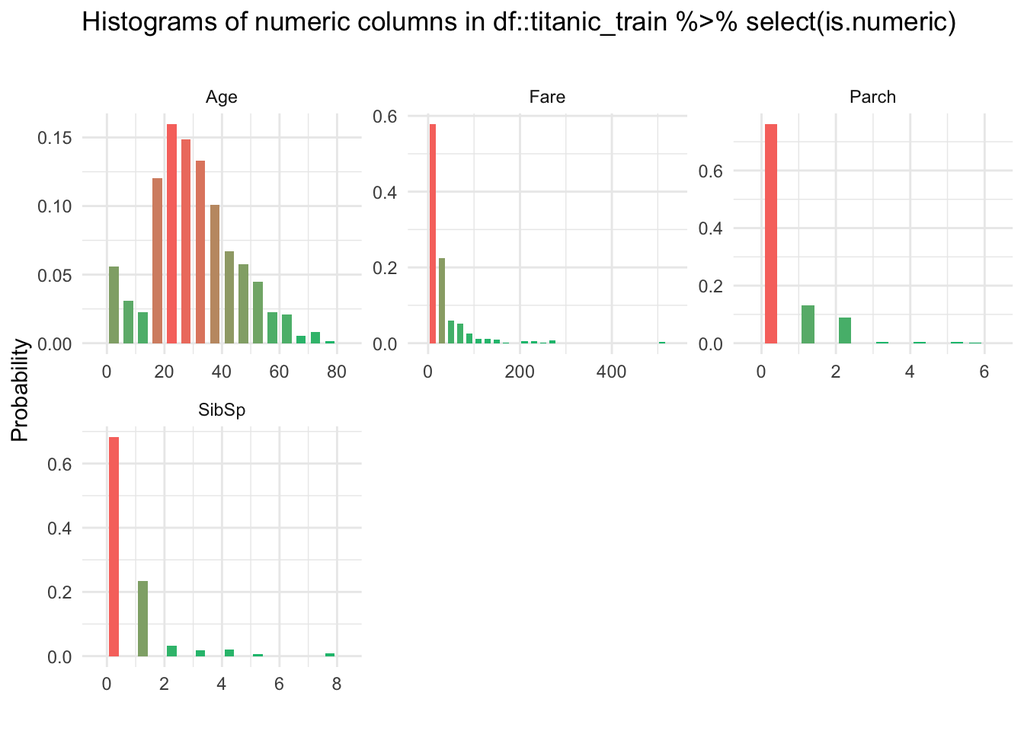

```r
show_plot(inspection)
```

As can be seen from the charts above, the data are not perfectly normally distributed, and hence, imputation with median value might be a more reasonable decision to complete the data set.

## Replace missing values

The following section is going to fill the missing values in both data sets using the median value of each respective column.

```r
#Replace the missing values in both data set using the median data
prevaluesTrain <- preProcess(titanic_train, method = c("medianImpute"))
prevaluesTest <- preProcess(titanic_test, method = c("medianImpute"))
titanic_train <- predict(prevaluesTrain, titanic_train)
titanic_test <- predict(prevaluesTest, titanic_test)
```

```r
colSums(is.na(titanic_train))
```

```
## Survived   Pclass      Sex      Age    SibSp    Parch     Fare Embarked
##        0        0        0        0        0        0        0        0
```

```r
colSums(is.na(titanic_test))
```

```
##   Pclass      Sex      Age    SibSp    Parch     Fare Embarked
##        0        0        0        0        0        0        0
```

# Exploratory Data Analysis

Check the target variable proportion in our train data set to avoid bias in predicting the model.

```r
(table(titanic_train$Survived))
```

```
##
##   0   1
## 549 342
```

```r
prop.table(table(titanic_train$Survived))
```

```
##
##         0         1
## 0.6161616 0.3838384
```

As the survived variable is more skewed towards 0, which indicates a passenger’s inability to survive, a up-sampling is needed to even the outcome and prevent significant bias in our model. In this case, up-sampling is more suitable as the data size is not relatively big enough.

```r
titanic_train <- titanic_train %>% upSample(titanic_train$Survived)
table(titanic_train$Survived)
```

```
##
##   0   1
## 549 549
```

As based on the previous examination, it can be deduced that some of the variables are suited more properly as factor, the data set is left with just 4 numerical predictor variables, namely Fare, Parch, SibSp and Age. This next section is going to view the strength of the correlation between those two.

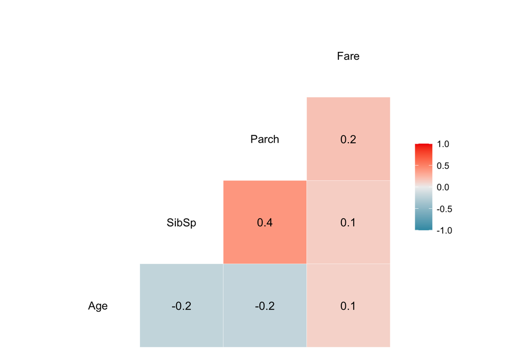

```r
ggcorr(titanic_train %>% select(-Survived), label = T)
```

As they are mainly mildly correlated, a model such as naive Bayes which depend immensely on the assumption of independent predictor variables might also be relevant in this prediction model.

# Modeling : Naive Bayes

Referencing another report written by Ms. Nabiilah of Algoritma Academy team which was published on RPubs(https://rpubs.com/nabiilahardini/wine-ndf), a naive Bayes model should satisfy the following characteristics : - assumes that all features of the dataset are equally important and independent. This allows Naive Bayes to perform faster computation (the algorithms is quite simple). - prone to bias due to data scarcity. In some cases, our data may have a distribution where scarce observations lead to probabilities approximating close to 0 or 1, which introduces a heavy bias into our model that could lead to poor performance on unseen data. - more appropriate for data with categoric predictors. This is because Naive Bayes is sensitive to data scarcity. Meanwhile, a continuous variable might contain really scarce or even only one observation for certain value. - apply Laplace estimator/smoothing for data scarcity problem. Laplace estimator proposes the adding of a small number (usually 1) to each of the counts in the frequency table. This subsequently ensures that each class-feature combination has a non-zero probability of occurring.

Considering the above mentioned characteristic of a suitable data set to be predicted using naive Bayes model, this titanic data is seemingly ideal to be predicted using this model, as it consists of lots of categorical columns.

```r
train_x <- titanic_train %>% select(-Survived)
train_y <- titanic_train$Survived
```

```r
naive_model <- naiveBayes(x = train_x, y = train_y, laplace = 1)

#model fitting using class prediction
naive_pred <- predict(naive_model, titanic_test, type="class")

#model fitting using prob prediction
naive_prob <- predict(naive_model, titanic_test, type="raw")

#result
naive_table <- select(answer, Survived) %>%
  bind_cols(survive_pred = naive_pred) %>%
  bind_cols(survive_eprob = round(naive_prob[,1],4)) %>%
  bind_cols(survive_pprob = round(naive_prob[,2],4))
```

```r
#performance evaluation using confusionMatrix
confusionMatrix(naive_pred, answer$Survived, positive = '1')
```

```
## Confusion Matrix and Statistics
##
##           Reference
## Prediction   0   1
##          0 228   8
##          1  38 144
##
##                Accuracy : 0.89
##                  95% CI : (0.8559, 0.9183)
##     No Information Rate : 0.6364
##     P-Value [Acc > NIR] : < 0.00000000000000022
##
##                   Kappa : 0.7719
##
##  Mcnemar's Test P-Value : 0.00001904
##
##             Sensitivity : 0.9474
##             Specificity : 0.8571
##          Pos Pred Value : 0.7912
##          Neg Pred Value : 0.9661
##              Prevalence : 0.3636
##          Detection Rate : 0.3445
##    Detection Prevalence : 0.4354
##       Balanced Accuracy : 0.9023
##
##        'Positive' Class : 1
##
```

```r
naive_table
```

| Survived | survive_pred | survive_eprob | survive_pprob |
| --- | --- | --- | --- |
| 0 | 0 | 0.8813 | 0.1187 |
| 1 | 1 | 0.4911 | 0.5089 |
| 0 | 0 | 0.7255 | 0.2745 |
| 0 | 0 | 0.9017 | 0.0983 |
| 1 | 1 | 0.4073 | 0.5927 |
| 0 | 0 | 0.8752 | 0.1248 |
| 1 | 1 | 0.3753 | 0.6247 |
| 0 | 0 | 0.7607 | 0.2393 |
| 1 | 1 | 0.1976 | 0.8024 |
| 0 | 0 | 0.9740 | 0.0260 |

[output cut: 408 more lines]

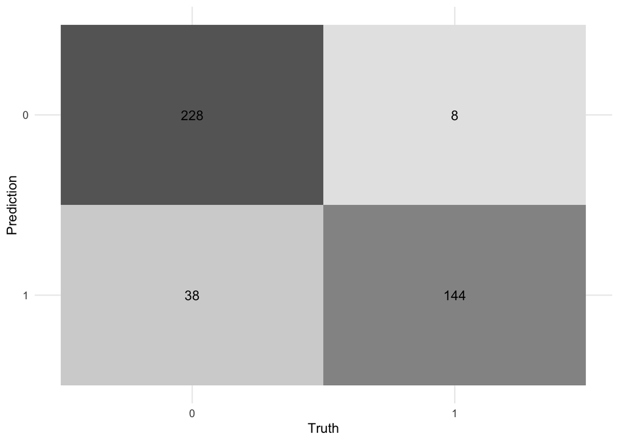

```r
#confusion matrix table
naive_table %>%
  conf_mat(Survived, survive_pred) %>%
  autoplot(type = "heatmap")
```

It can be seen that the model prediction has been able to predict the data set with reasonably high accuracy, as reflected on the recall. In this case, the correct prediction (passenger being alive) is set as the true positive as it might be better to falsely predict someone as alive compared to otherwise as it might lead to unwanted consequences (such as not searching for the person who is thought as dead). However, it is completely relative to the perspective of the person in generating this model and their objectives. The confusion matrix in the proceeding models will also have the same evaluation.

```r
naive_roc <- data.frame(prediction=round(naive_table$survive_pprob,4),
                      trueclass=as.numeric(naive_table$Survived=='1'))
(naive_roc)
```

| prediction | trueclass |
| --- | --- |
| 0.1187 | 0 |
| 0.5089 | 1 |
| 0.2745 | 0 |
| 0.0983 | 0 |
| 0.5927 | 1 |
| 0.1248 | 0 |
| 0.6247 | 1 |
| 0.2393 | 0 |
| 0.8024 | 1 |
| 0.0260 | 0 |

[output cut: 408 more lines]

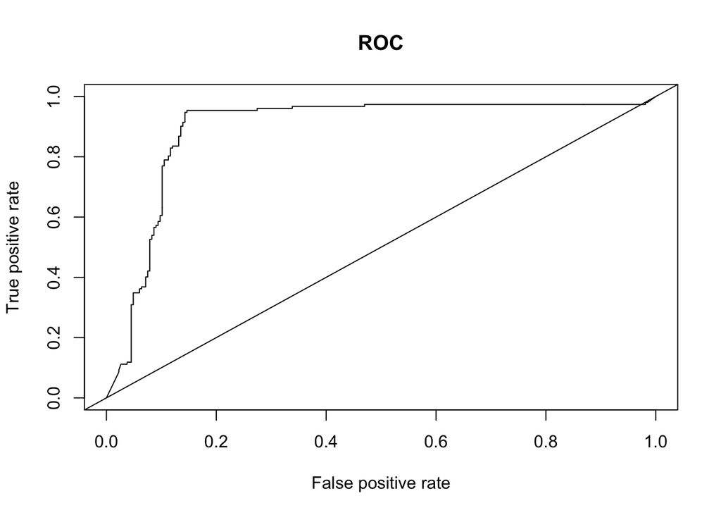

```
## integer(0)
```

```r
library(ROCR)
naive_roc <- ROCR::prediction(naive_roc$prediction, naive_roc$trueclass)

# ROC curve
plot(performance(naive_roc, "tpr", "fpr"),
     main = "ROC") +
     abline(a = 0, b = 1)
```

```r
# AUC
auc_ROCR_n <- performance(naive_roc, measure = "auc")
auc_ROCR_n <- auc_ROCR_n@y.values[[1]]
auc_ROCR_n
```

```
## [1] 0.8935868
```

```r
# Metrics result
final_n <- naive_table %>%
  summarise(
    accuracy = accuracy_vec(Survived, survive_pred),
    sensitivity = sens_vec(Survived, survive_pred),
    specificity = spec_vec(Survived, survive_pred),
    precision = precision_vec(Survived, survive_pred)
  ) %>%
  cbind(AUC = auc_ROCR_n)
final_n
```

| accuracy | sensitivity | specificity | precision | AUC |
| --- | --- | --- | --- | --- |
| 0.8899522 | 0.8571429 | 0.9473684 | 0.9661017 | 0.8935868 |

# Modeling : Decision Tree

This model might be chosen more often than not due to its easier interpretation to the human eyes, as it resembles an actual tree.

## Preprocessing the train and test data

Remove the class column which is not used for our model.

```r
titanic_train <- titanic_train %>% select(-Class)
titanic_train
```

| Survived | Pclass | Sex | Age | SibSp | Parch | Fare | Embarked |
| --- | --- | --- | --- | --- | --- | --- | --- |
| 0 | 3 | male | 22.00 | 1 | 0 | 7.2500 | S |
| 0 | 3 | male | 35.00 | 0 | 0 | 8.0500 | S |
| 0 | 3 | male | 28.00 | 0 | 0 | 8.4583 | Q |
| 0 | 1 | male | 54.00 | 0 | 0 | 51.8625 | S |
| 0 | 3 | male | 2.00 | 3 | 1 | 21.0750 | S |
| 0 | 3 | male | 20.00 | 0 | 0 | 8.0500 | S |
| 0 | 3 | male | 39.00 | 1 | 5 | 31.2750 | S |
| 0 | 3 | female | 14.00 | 0 | 0 | 7.8542 | S |
| 0 | 3 | male | 2.00 | 4 | 1 | 29.1250 | Q |
| 0 | 3 | female | 31.00 | 1 | 0 | 18.0000 | S |

[output cut: 1088 more lines]

```r
ttree_test <- titanic_test %>% mutate(Survived = answer$Survived)
ttree_test
```

| Pclass | Sex | Age | SibSp | Parch | Fare | Embarked | Survived |
| --- | --- | --- | --- | --- | --- | --- | --- |
| 3 | male | 34.50 | 0 | 0 | 7.8292 | Q | 0 |
| 3 | female | 47.00 | 1 | 0 | 7.0000 | S | 1 |
| 2 | male | 62.00 | 0 | 0 | 9.6875 | Q | 0 |
| 3 | male | 27.00 | 0 | 0 | 8.6625 | S | 0 |
| 3 | female | 22.00 | 1 | 1 | 12.2875 | S | 1 |
| 3 | male | 14.00 | 0 | 0 | 9.2250 | S | 0 |
| 3 | female | 30.00 | 0 | 0 | 7.6292 | Q | 1 |
| 2 | male | 26.00 | 1 | 1 | 29.0000 | S | 0 |
| 3 | female | 18.00 | 0 | 0 | 7.2292 | C | 1 |
| 3 | male | 21.00 | 2 | 0 | 24.1500 | S | 0 |

[output cut: 408 more lines]

## Make a decision tree model

```r
library(partykit)
```

[figure not shown]

```r
ttree_model <- ctree(formula = Survived ~.,
                     data = titanic_train,
                     control = ctree_control(mincriterion=0.005,
                                             minsplit=0,
                                             minbucket=0))

plot(ttree_model, type = "simple")
```

## Prediction and Confusion Matrix

```r
dtree_pred <- predict(ttree_model, ttree_test, type = "response")

dtree_prob <- predict(ttree_model, ttree_test, type = "prob")

dtree_table <- select(answer, Survived) %>%
  bind_cols(survive_pred = dtree_pred) %>%
  bind_cols(survive_eprob = round(dtree_prob[,1],4)) %>%
  bind_cols(survive_pprob = round(dtree_prob[,2],4))
```

```r
confusionMatrix(data = dtree_pred,
                reference = answer$Survived,
                positive = '1')
```

```
## Confusion Matrix and Statistics
##
##           Reference
## Prediction   0   1
##          0 213  42
##          1  53 110
##
##                Accuracy : 0.7727
##                  95% CI : (0.7295, 0.812)
##     No Information Rate : 0.6364
##     P-Value [Acc > NIR] : 0.000000001348
##
##                   Kappa : 0.5164
##
##  Mcnemar's Test P-Value : 0.3049
##
##             Sensitivity : 0.7237
##             Specificity : 0.8008
##          Pos Pred Value : 0.6748
##          Neg Pred Value : 0.8353
##              Prevalence : 0.3636
##          Detection Rate : 0.2632
##    Detection Prevalence : 0.3900
##       Balanced Accuracy : 0.7622
##
##        'Positive' Class : 1
##
```

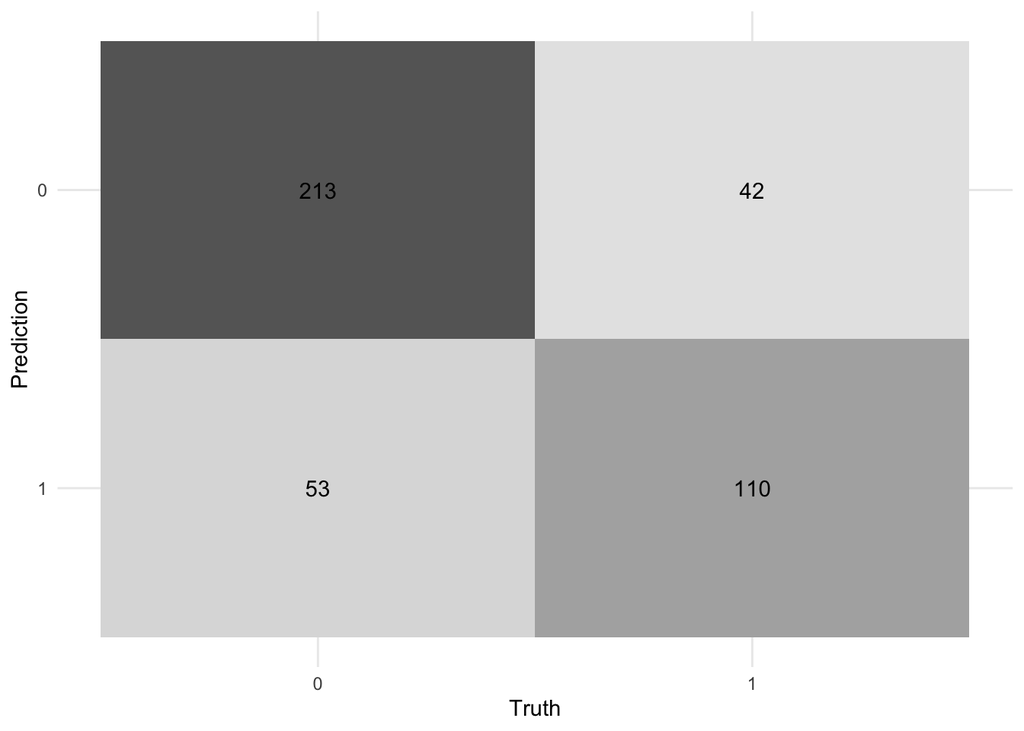

```r
#confusion matrix table
dtree_table %>%
  conf_mat(Survived, survive_pred) %>%
  autoplot(type = "heatmap")
```

## ROC

```r
dtree_roc <- data.frame(prediction=round(dtree_table$survive_pprob,4),
                      trueclass=as.numeric(dtree_table$Survived=='1'))
(dtree_roc)
```

|  | prediction | trueclass |
| --- | --- | --- |
| 1 | 0.1538 | 0 |
| 2 | 0.0000 | 1 |
| 3 | 0.1538 | 0 |
| 4 | 0.1538 | 0 |
| 5 | 0.0000 | 1 |
| 6 | 0.1538 | 0 |
| 7 | 0.0000 | 1 |
| 8 | 0.0000 | 0 |
| 9 | 0.0000 | 1 |
| 10 | 0.1538 | 0 |

[output cut: 408 more lines]

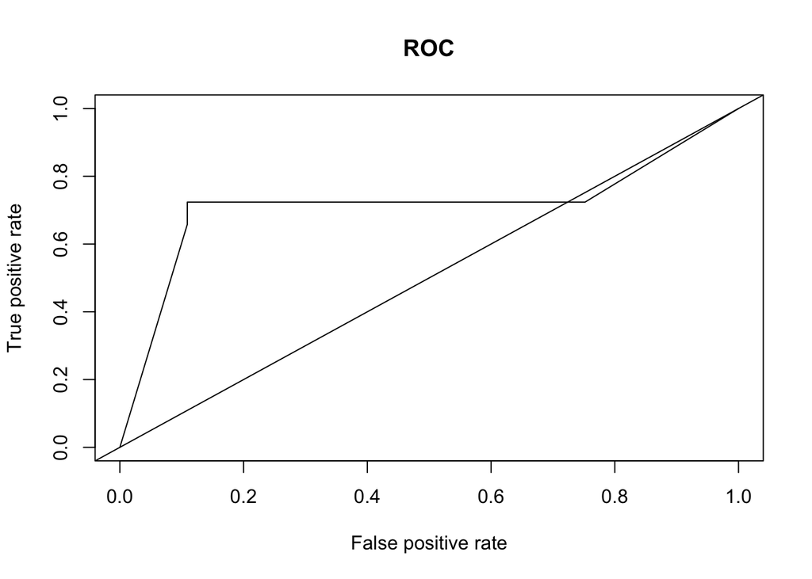

```
## integer(0)
```

```r
dtree_roc <- ROCR::prediction(dtree_roc$prediction, dtree_roc$trueclass)

# ROC curve
plot(performance(dtree_roc, "tpr", "fpr"),
     main = "ROC") +
     abline(a = 0, b = 1)
```

## AUC

```r
# AUC
auc_ROCR_d <- performance(dtree_roc, measure = "auc")
auc_ROCR_d <- auc_ROCR_d@y.values[[1]]
auc_ROCR_d
```

```
## [1] 0.7149288
```

##Metrics Result

```r
# Metrics result
final_d <- dtree_table %>%
  summarise(
    accuracy = accuracy_vec(Survived, survive_pred),
    sensitivity = sens_vec(Survived, survive_pred),
    specificity = spec_vec(Survived, survive_pred),
    precision = precision_vec(Survived, survive_pred)
  ) %>%
  cbind(AUC = auc_ROCR_d)
final_d
```

| accuracy | sensitivity | specificity | precision | AUC |
| --- | --- | --- | --- | --- |
| 0.7727273 | 0.8007519 | 0.7236842 | 0.8352941 | 0.7149288 |

# Modeling : Random Forest

Further referencing Ms. Nabiilah’s report, "Random Forest is one example of an ensemble-based algorithm which was built based on a decision tree method and known for its versatility and performance. Ensemble-based algorithm itself is actually a hybrid of several machine learning techniques combined into one predictive model, built to reduce error, bias, and improve predictions. The building of a Random Forest model consist of several steps:

it performs bagging (bootstrap aggregation) Creating subsets of training data through random sampling with replacement to train multiple predictive models (in this case many decision trees).

it performs boosting Train multiple predictive models to generate a better one. This overcomes the problem of overfitting in decision tree because we will consider more than 1 decision tree which was previously trained using random variables and observations.

classify class based on voting mechanism after multiple decision trees have been trained and each tree gave prediction (fitted values). The final prediction was generated through majority voting (in classification) or average output (if regression).

## Make a random forest model

```r
# model building
set.seed(100)
ctrl <- trainControl(method="repeatedcv", number=8, repeats=8) # k-fold cross validation
tforest <- train(Survived ~ ., data=titanic_train, method="rf", trControl = ctrl)
tforest
```

```
## Random Forest
##
## 1098 samples
##    7 predictor
##    2 classes: '0', '1'
##
## No pre-processing
## Resampling: Cross-Validated (8 fold, repeated 8 times)
## Summary of sample sizes: 960, 961, 961, 961, 960, 961, ...
## Resampling results across tuning parameters:
##
##   mtry  Accuracy   Kappa
##    2    0.8192259  0.6384045
##    6    0.8689785  0.7379404
##   10    0.8693091  0.7386040
##
## Accuracy was used to select the optimal model using the largest value.
## The final value used for the model was mtry = 10.
```

## Inspect the importance of each variable

```r
varImp(tforest)
```

```
## rf variable importance
##
##           Overall
## Sexmale   100.000
## Fare       93.871
## Age        86.857
## Pclass3    16.510
## SibSp      13.117
## Parch       6.695
## EmbarkedS   3.820
## Pclass2     3.792
## EmbarkedC   3.403
## EmbarkedQ   0.000
```

## final model of forest

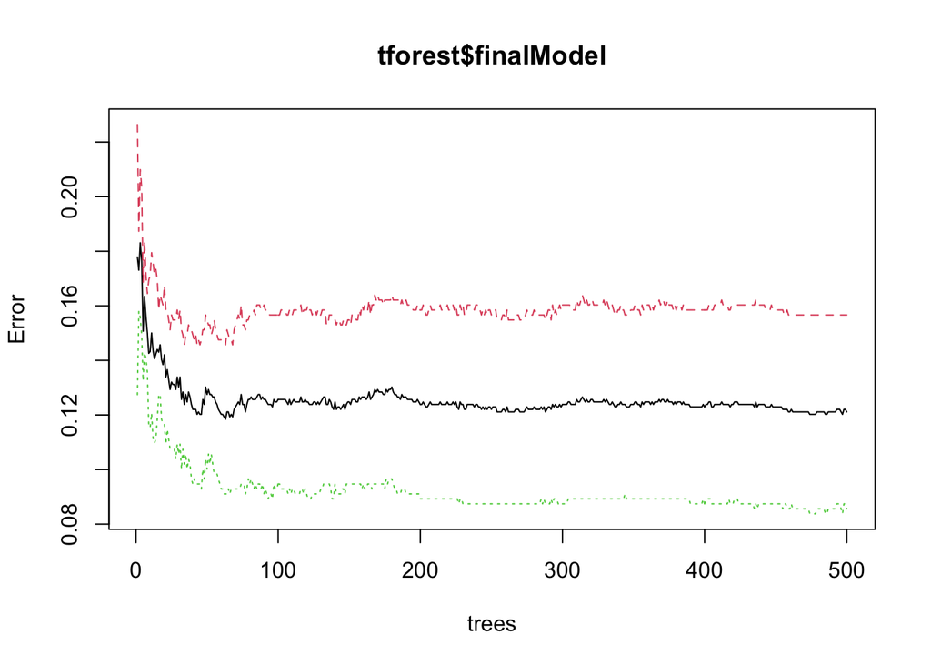

```r
plot(tforest$finalModel)
```

```r
tforest$finalModel
```

```
##
## Call:
##  randomForest(x = x, y = y, mtry = param$mtry)
##                Type of random forest: classification
##                      Number of trees: 500
## No. of variables tried at each split: 10
##
##         OOB estimate of  error rate: 12.11%
## Confusion matrix:
##     0   1 class.error
## 0 463  86   0.1566485
## 1  47 502   0.0856102
```

## Predict the model

```r
tforest_pred <- predict(tforest, titanic_test, type="raw")

tforest_prob <- predict(tforest, titanic_test, type="prob")

forest_table <- select(answer, Survived) %>%
  bind_cols(survive_pred = tforest_pred) %>%
  bind_cols(survive_eprob = round(tforest_prob[,1],4)) %>%
  bind_cols(survive_pprob = round(tforest_prob[,2],4))
```

## Confusion Matrix

```r
confusionMatrix(tforest_pred, answer$Survived, positive = '1')
```

```
## Confusion Matrix and Statistics
##
##           Reference
## Prediction   0   1
##          0 208  28
##          1  58 124
##
##                Accuracy : 0.7943
##                  95% CI : (0.7523, 0.832)
##     No Information Rate : 0.6364
##     P-Value [Acc > NIR] : 0.000000000001798
##
##                   Kappa : 0.5735
##
##  Mcnemar's Test P-Value : 0.001765
##
##             Sensitivity : 0.8158
##             Specificity : 0.7820
##          Pos Pred Value : 0.6813
##          Neg Pred Value : 0.8814
##              Prevalence : 0.3636
##          Detection Rate : 0.2967
##    Detection Prevalence : 0.4354
##       Balanced Accuracy : 0.7989
##
##        'Positive' Class : 1
##
```

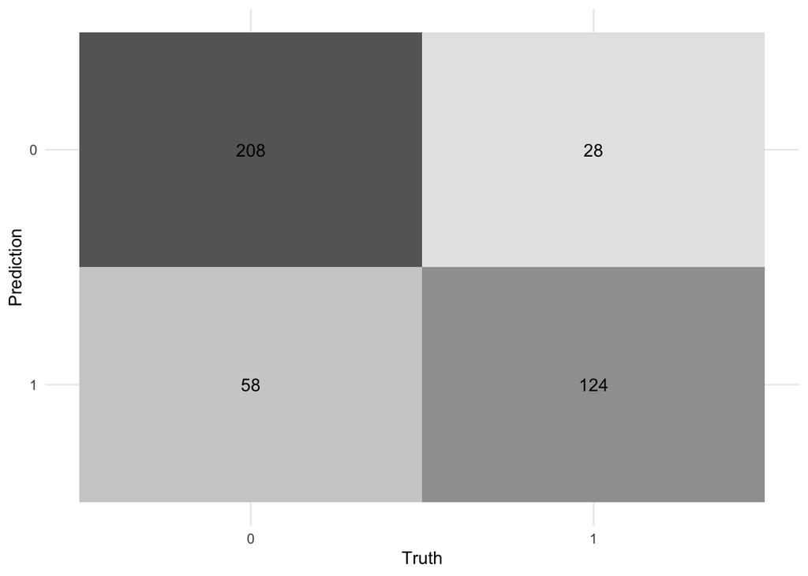

```r
#confusion matrix table
forest_table %>%
  conf_mat(Survived, survive_pred) %>%
  autoplot(type = "heatmap")
```

## ROC

```r
forest_roc <- data.frame(prediction=round(forest_table$survive_pprob,4),
                      trueclass=as.numeric(forest_table$Survived=='1'))
(forest_roc)
```

| prediction | trueclass |
| --- | --- |
| 0.172 | 0 |
| 0.126 | 1 |
| 0.778 | 0 |
| 0.866 | 0 |
| 0.550 | 1 |
| 0.156 | 0 |
| 0.142 | 1 |
| 0.078 | 0 |
| 0.888 | 1 |
| 0.102 | 0 |

[output cut: 408 more lines]

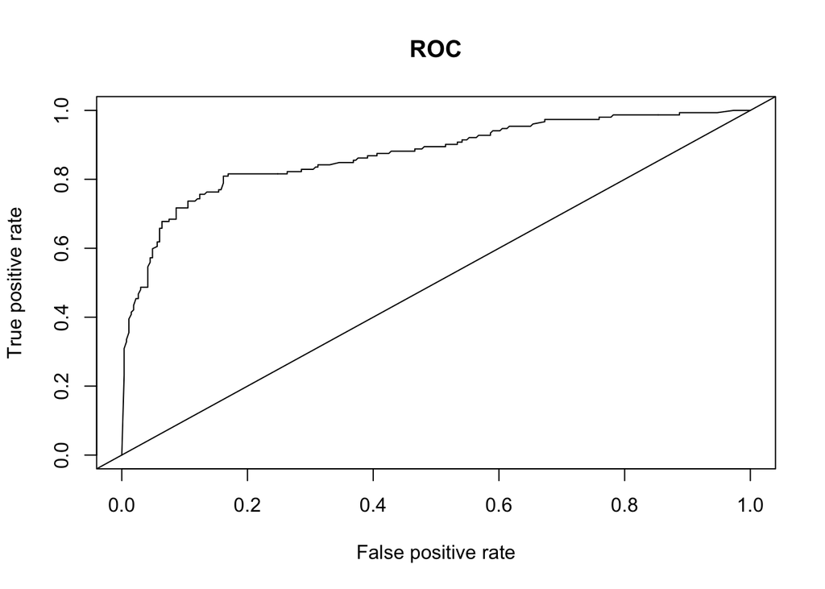

```
## integer(0)
```

```r
forest_roc <- ROCR::prediction(forest_roc$prediction, forest_roc$trueclass)

# ROC curve
plot(performance(forest_roc, "tpr", "fpr"),
     main = "ROC") +
     abline(a = 0, b = 1)
```

## AUC

```r
# AUC
auc_ROCR_f <- performance(forest_roc, measure = "auc")
auc_ROCR_f <- auc_ROCR_f@y.values[[1]]
auc_ROCR_f
```

```
## [1] 0.8717476
```

## Metrics Result

```r
# Metrics result
final_f <- forest_table %>%
  summarise(
    accuracy = accuracy_vec(Survived, survive_pred),
    sensitivity = sens_vec(Survived, survive_pred),
    specificity = spec_vec(Survived, survive_pred),
    precision = precision_vec(Survived, survive_pred)
  ) %>%
  cbind(AUC = auc_ROCR_f)
final_f
```

| accuracy | sensitivity | specificity | precision | AUC |
| --- | --- | --- | --- | --- |
| 0.7942584 | 0.7819549 | 0.8157895 | 0.8813559 | 0.8717476 |

# Conclusion

```r
rbind("Naive Bayes" = final_n, "Decision Tree" = final_d, "Random Forest" = final_f)
```

|  | accuracy | sensitivity | specificity | precision | AUC |
| --- | --- | --- | --- | --- | --- |
| Naive Bayes | 0.8899522 | 0.8571429 | 0.9473684 | 0.9661017 | 0.8935868 |
| Decision Tree | 0.7727273 | 0.8007519 | 0.7236842 | 0.8352941 | 0.7149288 |
| Random Forest | 0.7942584 | 0.7819549 | 0.8157895 | 0.8813559 | 0.8717476 |